# Analyzing Food Security Trends and Disparities in the U.S.

Author

Hailey Hon, Joshua Joshua, Tien Nguyen, Quynh Giang Tran, Michael Chan

## **Data Source**

This analysis is based on data from the IPUMS Current Population Survey (CPS) Food Security Supplement. [here.](https://cps.ipums.org/cps-action/variables/group/h-foodsec_foodsec?page=1)

## **Objective**

Our study examines food security trends in the United States from 2016 to 2023, focusing on disparities across socioeconomic factors. By uncovering correlations between food security and key demographic variables, we aim to provide insights that can inform policy decisions to mitigate food insecurity.

## **Introduction**

[Food insecurity is impacting one out of eight American adults | USAFacts](https://usafacts.org/articles/food-insecurity-in-the-us/)

The United States is currently facing significant challenges in food security, exacerbated by the interplay of economic policies and global market dynamics. Tariffs and trade tensions have contributed to rising production and import costs, which in turn elevate food prices. This issue is further compounded by inflation, disproportionately impacting low-income households that already struggle to afford basic necessities. The soaring cost of staples, such as eggs, serves as a striking example of how quickly and dramatically these changes can burden millions of Americans.

We aim to find insights into food security and identify correlations between socioeconomic factors to help policymakers make informed decisions in addressing this issue.

## **Key Findings and Visualizations**

### 1. Food Insecurity Trends Over Time

*“How has food insecurity changed over the years, and what factors may have influenced these trends?”*

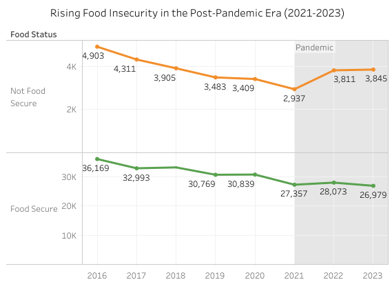

This shift highlights the pandemic’s impact on economic stability and access to food resources. The trends suggest that factors such as job losses, inflation, and supply chain disruptions likely contributed to food insecurity. Further analysis is needed to explore how government assistance programs (such as SNAP) and socio-demographic differences influence these changes.

### 2. Food Insecurity Among SNAP Recipients

To address food insecurity, the U.S. government provides food assistance through the Supplemental Nutrition Assistance Program (SNAP), commonly known as food stamps. This program is a key factor in our analysis, as it represents a government initiative aimed at supporting individuals facing financial hardship.

*How does the proportion of food security differ by food stamp eligibility?*

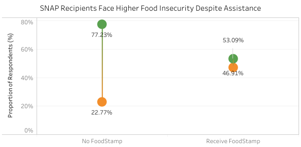

Our research examines the relationship between food security and SNAP eligibility. The data reveals a significant disparity: among SNAP recipients, **46.91%** experience low food security, while **53.09%** are food secure. In contrast, only **22.77%** of individuals who do not receive SNAP benefits report low food security, with **77.23%** being food secure. The data suggests that SNAP recipients remain more vulnerable to low food security compared to non-recipients, despite receiving government assistance. This may indicate that while SNAP provides critical support, it may not be sufficient to fully mitigate food insecurity for all recipients

### 3. Education Level and Food Security

Education plays a crucial role in determining financial stability, employment opportunities, and access to resources, all of which directly impact food security. Individuals with higher education levels often have better financial prospects, which can reduce the likelihood of food insecurity. Conversely, those with lower education levels may face economic challenges that increase their risk of food insecurity. This visualization explores the connection between educational attainment and food security outcomes.

*How does educational attainment impact food security, and what patterns emerge across different education levels?*

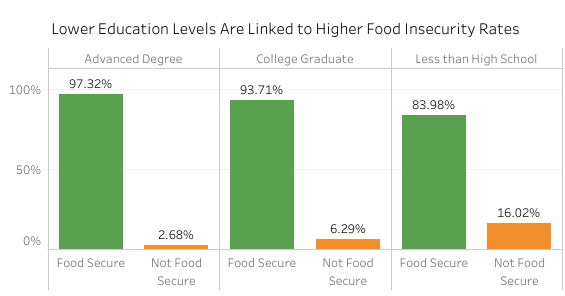

The graph illustrates the strong correlation between education levels and food security, showing that individuals with lower education levels are more likely to experience food insecurity. Food security is highest among those with an advanced degree (**97.32%** food secure, **2.68%** food insecure), followed by college graduates (**93.71%** food secure, **6.29%** food insecure). In contrast, individuals with less than a high school education face the highest risk, with only **83.98%** food secure and **16.02%** experiencing food insecurity.

This trend suggests that higher education contributes to financial stability, better employment opportunities, and improved access to resources, all of which reduce food insecurity. Conversely, those with lower educational attainment may struggle with limited job prospects and lower incomes, increasing their risk. The significant **13.34** percentage point gap in food insecurity between those with an advanced degree **(2.68%)** and those with less than a high school education **(16.02%)** highlights the direct impact of education on economic stability.

### 4. Disability Status and Food Security

In addition to education, disability is another critical economic variable that may further contribute to financial instability and an increased risk of food security. Understanding the relationship between disability status and food security is critical in identifying vulnerable populations and addressing disparities in food access. Individuals with disabilities often face additional barriers that may contribute to food insecurity, such as limited employment opportunities, increased medical costs, and challenges in accessing government assistance programs. This visualization examines the extent to which disability status impacts food security outcomes.

*How does disability status affect food security, and what factors contribute to this disparity?*

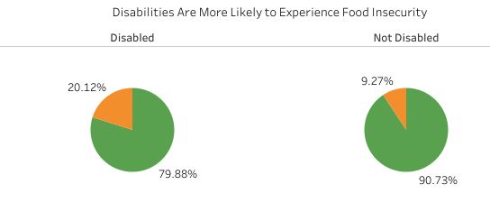

The graph highlights the disparity in food security between individuals with disabilities and those without. Among disabled individuals, **20.12%** experience food insecurity, compared to only **9.27%** of non-disabled individuals. Conversely, **79.88%** of disabled individuals are food secure, while **90.73%** of non-disabled individuals have adequate access to food. This data suggests that individuals with disabilities face a higher risk of food insecurity, potentially due to factors such as limited income, employment barriers, increased medical expenses, or challenges in accessing food assistance programs.

### 5. Marital Status and Food Security

Just as disability status impacts food security disparities, marital status also plays a critical role.

*How does marital status impact food insecurity rates?*

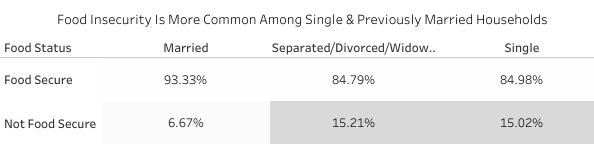

Our analysis shows that food insecurity is more prevalent among single and previously married households compared to married individuals. While only **6.67%** of married individuals experience food insecurity, the rates are significantly higher for those who are separated, divorced, widowed (**15.21%**) and single (**15.02%**). This disparity suggests that financial stability and shared resources such as a **dual-income household**—may provide greater food security for married individuals, whereas single and previously married individuals may face greater economic challenges due to reliance on a single income or financial strain from separation. Addressing these disparities may require targeted policies and assistance programs to support individuals at higher risk, considering additional factors such as employment status, household size, and access to food assistance programs.

## **Conclusion and Recommendations**

Key Takeaways and Recommendations:

- **Government Assistance Gaps** – Nearly half of SNAP recipients still experience food insecurity, indicating a need for increased benefits and improved access to nutritious food.
- **Education as a Protective Factor** – Higher education levels strongly correlate with increased food security, underscoring the importance of expanding education and workforce training programs.
- **Vulnerability Among Disabled Individuals** – Higher food insecurity rates among individuals with disabilities point to the need for targeted support and policy interventions.
- **Economic Disparities by Marital Status** – Single and previously married individuals are more likely to experience food insecurity, suggesting the need for financial assistance programs tailored to these groups.
- **Further Research on Pandemic Impact** – Assess long-term economic effects to guide future interventions.

By enhancing food assistance programs, expanding educational opportunities, and implementing targeted policies for vulnerable populations, policymakers and community organizations can work toward reducing food insecurity and ensuring equitable access to nutritious food.